# R Notebook

# Follows from: orthology_maps_data_inputs.Rmd.

# (Can) work in parallel with: ciona_larvae_clustering.Rmd.

# General Description: Maps all cell types using Wagner’s DEGs in zeb_integrated_50.

# Note: This script is used for visualization for Tissue Mapping only!

# ClusterIDs are present in zeb_degs_heatmaps.Rmd.

# Env used: env_zeb_24hpf_clustering.RData.

# Complete Pipeline:

# (1) Makes zeb_*t2_24hpf_seurat (6 of them, _t5). These are unscaled. # (2) Uses above to make various integrated objects (vary in # anchors). # (3) Ultimately, zeb_integrated_50 is used for tissue mapping.

# Other Contents:

# DEGs from Wagner Supplement Table 2 for all tissues.

# Batch correction plots, summary stats.

# Notes:

# Unused markers (Zfin, Andrea) at bottom.

# zeb_integrated_* (10, 30 , 70) have been removed from .Renv.

# Segways into: zeb_degs_heatmaps.Rmd.

```r
library(Seurat)
library(dplyr)
library(ggplot2)
library(purrr)
library(Hmisc)
library(pvclust)
```

KLEIN ZEBRAFISH

# Extract individual Raw UMI-filtered counts (csv). Example below.

# https://www.ncbi.nlm.nih.gov/geo/query/acc.cgi?acc=GSM3067195

# GSM3067195_24hpf.csv.gz

# [LOC100000009 x DEW050_GTCTCTCT_AGGAGCTT]

# 30677 x *

```r
zeb_24hpf_dir <- "/home/pprakriti/princeton_google_drive/Levine Lab/Orthology-Maps/Raw_Data/Klein_2018/GSM3067195_24hpf.csv"
# 7970
zeb_24hpf_df <- read.table(zeb_24hpf_dir,
                          sep = ",",
                          header = TRUE,
                          stringsAsFactors = FALSE)
# Clean up the dataframe
rownames(zeb_24hpf_df) <- zeb_24hpf_df$Row
zeb_24hpf_df$Row <- NULL
```

# Helper Function to make above raw matrix data frames

```r
make_zeb_df <- function(zeb_dir) {
  zeb_df <- read.table(zeb_dir,
                       sep = ",",
                       header = TRUE,
                       stringsAsFactors = FALSE)

  rownames(zeb_df) <- zeb_df$Row
  zeb_df$Row <- NULL

  return(zeb_df)
}
```

""" Make all raw matrix data frames """

# T = 34750 (exactly what is reported in Fig S2B)

https://www.ncbi.nlm.nih.gov/geo/query/acc.cgi?acc=GSM3067196,

```r
zeb_t1_dir <- "/home/pprakriti/princeton_google_drive/Levine Lab/Orthology-Maps/Raw_Data/Klein_2018/GSM3067196_TracerSeq1.csv"
zeb_t1_24hpf_df <- make_zeb_df(zeb_t1_dir)
```

https://www.ncbi.nlm.nih.gov/geo/query/acc.cgi?acc=GSM3067197,

```r
zeb_t2_dir <- "/home/pprakriti/princeton_google_drive/Levine Lab/Orthology-Maps/Raw_Data/Klein_2018/GSM3067197_TracerSeq2.csv"
#
zeb_t2_24hpf_df <- make_zeb_df(zeb_t2_dir)
```

https://www.ncbi.nlm.nih.gov/geo/query/acc.cgi?acc=GSM3067198,

```r
zeb_t3_dir <- "/home/pprakriti/princeton_google_drive/Levine Lab/Orthology-Maps/Raw_Data/Klein_2018/GSM3067198_TracerSeq3.csv"
# 5752
zeb_t3_24hpf_df <- make_zeb_df(zeb_t3_dir)
```

https://www.ncbi.nlm.nih.gov/geo/query/acc.cgi?acc=GSM3067199,

```r
zeb_t4_dir <- "/home/pprakriti/princeton_google_drive/Levine Lab/Orthology-Maps/Raw_Data/Klein_2018/GSM3067199_TracerSeq4.csv"
#
zeb_t4_24hpf_df <- make_zeb_df(zeb_t4_dir)
```

https://www.ncbi.nlm.nih.gov/geo/query/acc.cgi?acc=GSM3067200

```r
zeb_t5_dir <- "/home/pprakriti/princeton_google_drive/Levine Lab/Orthology-Maps/Raw_Data/Klein_2018/GSM3067200_TracerSeq5.csv"
#
zeb_t5_24hpf_df <- make_zeb_df(zeb_t5_dir)
```

""" Let’s pool all the data together and batch correct raw matrix values """

# https://satijalab.org/seurat/v3.1/integration.html

# (1) Perform standard pre-processing steps on each Seurat object.

```r
make_zeb_seurat <- function(zeb_df, min_cells, min_features, n_features){
  zeb_seurat <- CreateSeuratObject(counts = zeb_df,
                                   min.cells = min_cells,
                                   min.features = min_features)

  zeb_seurat <- NormalizeData(object = zeb_seurat)

  zeb_seurat <- FindVariableFeatures(zeb_seurat,
                                     selection.method = "vst",
                                     nfeatures = n_features)
  return(zeb_seurat)
  }
```

# (2) Make the individual Seurat Objects

```r
zeb_t1_24hpf_seurat <- make_zeb_seurat(zeb_t1_24hpf_df,
                                    zeb_min_cells,
                                    zeb_min_features,
                                    zeb_n_features)
```

```
Feature names cannot have underscores ('_'), replacing with dashes ('-')Performing log-normalization
```

```r
zeb_t2_24hpf_seurat <- make_zeb_seurat(zeb_t2_24hpf_df,
                                    zeb_min_cells,
                                    zeb_min_features,
                                    zeb_n_features)
```

```
Feature names cannot have underscores ('_'), replacing with dashes ('-')Performing log-normalization
```

```r
zeb_t3_24hpf_seurat <- make_zeb_seurat(zeb_t3_24hpf_df,
                                    zeb_min_cells,
                                    zeb_min_features,
                                    zeb_n_features)
```

```
Feature names cannot have underscores ('_'), replacing with dashes ('-')Performing log-normalization
```

```r
zeb_t4_24hpf_seurat <- make_zeb_seurat(zeb_t4_24hpf_df,
                                    zeb_min_cells,
                                    zeb_min_features,
                                    zeb_n_features)
```

```
Feature names cannot have underscores ('_'), replacing with dashes ('-')Performing log-normalization
```

```r
zeb_t5_24hpf_seurat <- make_zeb_seurat(zeb_t5_24hpf_df,
                                    zeb_min_cells,
                                    zeb_min_features,
                                    zeb_n_features)
```

```
Feature names cannot have underscores ('_'), replacing with dashes ('-')Performing log-normalization
```

""" Make list of above Seurat Objects """

```r
zeb_seurat_list = list(zeb_24hpf_seurat, zeb_t1_24hpf_seurat, zeb_t2_24hpf_seurat, zeb_t3_24hpf_seurat, zeb_t4_24hpf_seurat, zeb_t5_24hpf_seurat)
```

""" Integration Routine- First pass on 30 anchors """

```r
zeb_anchors <- FindIntegrationAnchors(object.list = zeb_seurat_list,
                                      dims = 1:30)
```

```
Computing 2000 integration features
Scaling features for provided objects
```

[output not shown]

```
Finding all pairwise anchors
```

```
  |                                                  | 0 % ~calculating
```

[output not shown]

```
  |++++                                              | 7 % ~42m 15s
```

[output not shown]

```
  |+++++++                                           | 13% ~49m 60s
```

```
Running CCA
Merging objects
Finding neighborhoods
Finding anchors
    Found 14860 anchors
Filtering anchors
    Retained 12291 anchors
Extracting within-dataset neighbors
```

```
  |++++++++++                                        | 20% ~44m 04s
```

```
Running CCA
Merging objects
Finding neighborhoods
Finding anchors
    Found 8504 anchors
Filtering anchors
    Retained 7563 anchors
Extracting within-dataset neighbors
```

```
  |++++++++++++++                                    | 27% ~34m 35s
```

```
Running CCA
Merging objects
Finding neighborhoods
Finding anchors
    Found 8340 anchors
Filtering anchors
    Retained 7561 anchors
Extracting within-dataset neighbors
```

```
  |+++++++++++++++++                                 | 33% ~27m 18s
```

```
Running CCA
Merging objects
Finding neighborhoods
Finding anchors
    Found 9285 anchors
Filtering anchors
    Retained 8705 anchors
Extracting within-dataset neighbors
```

```
  |++++++++++++++++++++                              | 40% ~22m 60s
```

```
Running CCA
Merging objects
Finding neighborhoods
Finding anchors
    Found 13472 anchors
Filtering anchors
    Retained 10720 anchors
Extracting within-dataset neighbors
```

```
  |++++++++++++++++++++++++                          | 47% ~21m 19s
```

```
Running CCA
Merging objects
Finding neighborhoods
Finding anchors
    Found 12659 anchors
Filtering anchors
    Retained 10460 anchors
Extracting within-dataset neighbors
```

```
  |+++++++++++++++++++++++++++                       | 53% ~18m 23s
```

```
Running CCA
Merging objects
Finding neighborhoods
Finding anchors
    Found 15295 anchors
Filtering anchors
    Retained 12880 anchors
Extracting within-dataset neighbors
```

```
  |++++++++++++++++++++++++++++++                    | 60% ~16m 26s
```

```
Running CCA
Merging objects
Finding neighborhoods
Finding anchors
    Found 8644 anchors
Filtering anchors
    Retained 7062 anchors
Extracting within-dataset neighbors
```

```
  |++++++++++++++++++++++++++++++++++                | 67% ~12m 55s
```

```
Running CCA
Merging objects
Finding neighborhoods
Finding anchors
    Found 8331 anchors
Filtering anchors
    Retained 7482 anchors
Extracting within-dataset neighbors
```

```
  |+++++++++++++++++++++++++++++++++++++             | 73% ~09m 58s
```

```
Running CCA
Merging objects
Finding neighborhoods
Finding anchors
    Found 8199 anchors
Filtering anchors
    Retained 7558 anchors
Extracting within-dataset neighbors
```

```
  |++++++++++++++++++++++++++++++++++++++++          | 80% ~07m 08s
```

```
Running CCA
Merging objects
Finding neighborhoods
Finding anchors
    Found 9434 anchors
Filtering anchors
    Retained 8794 anchors
Extracting within-dataset neighbors
```

```
  |++++++++++++++++++++++++++++++++++++++++++++      | 87% ~04m 39s
```

```
Running CCA
Merging objects
Finding neighborhoods
Finding anchors
    Found 6165 anchors
Filtering anchors
    Retained 5522 anchors
Extracting within-dataset neighbors
```

```
  |+++++++++++++++++++++++++++++++++++++++++++++++   | 93% ~02m 12s
```

```
Running CCA
Merging objects
Finding neighborhoods
Finding anchors
    Found 8649 anchors
Filtering anchors
    Retained 8047 anchors
Extracting within-dataset neighbors
```

```
  |++++++++++++++++++++++++++++++++++++++++++++++++++| 100% elapsed=32m 01s
```

```r
zeb_integrated <- IntegrateData(anchorset = zeb_anchors, dims = 1:30)
```

```
Merging dataset 6 into 3
Extracting anchors for merged samples
Finding integration vectors
Finding integration vector weights
Integrating data
Merging dataset 4 into 1
Extracting anchors for merged samples
Finding integration vectors
Finding integration vector weights
Integrating data
Merging dataset 2 into 3 6
Extracting anchors for merged samples
Finding integration vectors
Finding integration vector weights
Integrating data
Merging dataset 5 into 3 6 2
Extracting anchors for merged samples
Finding integration vectors
Finding integration vector weights
Integrating data
Merging dataset 1 4 into 3 6 2 5
Extracting anchors for merged samples
Finding integration vectors
Finding integration vector weights
Integrating data
Adding a command log without an assay associated with it
```

```r
DefaultAssay(zeb_integrated) <- "integrated"
# Run the standard workflow for visualization and clustering
zeb_integrated <- ScaleData(zeb_integrated, verbose = FALSE)
zeb_integrated <- RunPCA(zeb_integrated, npcs = 70, verbose = FALSE)
zeb_integrated <- RunTSNE(zeb_integrated, dims = 1:70)
#zeb_integrated <- FindNeighbors(zeb_integrated, dims = 1:70)
#zeb_integrated <- FindClusters(zeb_integrated, resolution = 4)
#zeb_integrated <- RunTSNE(zeb_integrated, dims = 1:70)
```

```r
zeb_integrated <- FindNeighbors(zeb_integrated, dims = 1:70)
zeb_integrated <- FindClusters(zeb_integrated, resolution = 2)
```

""" Turn above routine into a function """

# Helper Function

```r
make_integrated_seurat <- function(object_list, dims, npcs){
  # Args:
    # object_list: list of Seurat objects. e.g. zeb_seurat_list.
    # dims: input dimensions for FindIntegrationAnchors and IntegrateData.
    # npcs: # pcs for PCA and TSNE.

  # Routine: Do integration. Scale, PCA, TSNE.

  # Returns:
    # integrated_seurat: output of above routine.

  zeb_anchors <- FindIntegrationAnchors(object.list = object_list,
                                      dims = 1:dims)
  zeb_integrated <- IntegrateData(anchorset = zeb_anchors, dims = 1:dims)

  DefaultAssay(zeb_integrated) <- "integrated"

  zeb_integrated <- ScaleData(zeb_integrated, verbose = FALSE)
  zeb_integrated <- RunPCA(zeb_integrated, npcs = npcs, verbose = FALSE)
  zeb_integrated <- RunTSNE(zeb_integrated, dims = 1:npcs)

  return(zeb_integrated)
}
```

""" Make Various Integrated Objects """

# dims=10, npcs=70 - Done

```r
zeb_integrated_10 <- make_integrated_seurat(zeb_seurat_list, 10, 70)
```

# dims=50, npcs=70 - Done

```r
zeb_integrated_50 <- make_integrated_seurat(zeb_seurat_list, 50, 70)
```

# dims=70, npcs=70 - Done

```r
zeb_integrated_70 <- make_integrated_seurat(zeb_seurat_list, 70, 70)
```

""" Cluster Them """

# 50 - Done

```r
zeb_integrated_50 <- FindNeighbors(zeb_integrated_50, dims = 1:70)
zeb_integrated_50 <- FindClusters(zeb_integrated_50, resolution = 2)
```

# 70 - Done

```r
zeb_integrated_70 <- FindNeighbors(zeb_integrated_70, dims = 1:70)
zeb_integrated_70 <- FindClusters(zeb_integrated_70, resolution = 2)
```

```
Modularity Optimizer version 1.3.0 by Ludo Waltman and Nees Jan van Eck

Number of nodes: 34750
Number of edges: 2249704

Running Louvain algorithm...
```

```
Maximum modularity in 10 random starts: 0.8896
Number of communities: 77
Elapsed time: 9 seconds
```

```
1 singletons identified. 76 final clusters.
```

""" DEGs to Use: Supp Table 2 """

```r
# noto- DONE
noto_50_degs <- c("ntd5", "aplp2", "emilin3a", "pmp22b", "loxl5b", "ta", "si:dkey-12l12.1", "plod1a", "calua", "fstl1b", "fn1a", "LOC100333762", "col2a1a", "serpinh1b", "fxyd1", "LOC100149028", "fstl1a", "col11a1a", "cmn", "col2a1b", "emilin3a", "si:dkey-12l12.1", "loxl5b", "ta", "LOC100333762", "LOC1001|49028", "ntd5", "fxyd1", "cmn", "pmp22b", "fn1a", "plod1a", "serpinh1b", "calua", "aplp2", "col11a1a", "fstl1a", "col2a1a", "fstl1b", "col2a1b")


# Hearts (3) # - DONE
heart_51_degs <- c("si:dkey-261h17.1", "LOC100331639", "tpm4a", "krt18", "krt8", "pcolcea", "flna", "ftr82", "fn1a", "si:dkey-207j16.2", "rbpms2b", "krt94", "podxl", "myl9b", "LOC563082", "hand2", "colec10", "sfrp5", "fabp11a"  , "si:dkey-261h17.1", "pcolcea", "tmem88b", "krt18", "ftr82", "LOC100331639", "fn1a", "si:dkey-207j16.2", "krt8", "flna", "tpm4a", "rbpms2b", "krt94", "LOC563082", "myl9b", "hand2", "podxl", "colec10", "sfrp5", "fabp11a")

heart_mature_52_degs <- c("tpm4a", "fhl2a", "tnnt2a", "myl7", "tnnc1a")

heart_hox9da_56_degs <- c("si:dkey-261h17.1", "pmp22a", "prrx1a", "reck", "prdm1a", "aldh1a2")



# Muscles (3) # - DONE
mus_myl10_53_degs <- c("tpm3", "tpm2", "hm:zewp0073", "actc1a", "myl13")

mus_myl1_12_degs <- c("mylz3", "actc1a", "hm:zewp0073", "myl1", "mylpfa", "tpma", "tnnc2", "acta1b", "ckmb", "ckma", "actc1b")

myotome_27_degs <- c("hsp90aa1.1", "hm:zewp0073", "actc1a", "klhl41b", "myog", "pabpc4", "tnni2b.1", "myl1", "hspb1")



# Pancreas - DONE
panc_prim_4_degs <- c("slc1a4", "pax6b", "anxa4", "slc43a2a", "scg3", "isl1", "tspan7b", "rltgr", "scgn", "nucb2b", "neurod1", "LOC565781", "si:dkey-153k10.9")



# pharyngeal stuff (5) # - DONE
# same first 10
pharyn_pouch_28_degs <- c("epcam", "pax1b", "si:dkey-261h17.1", "krt18", "krt8", "egfl6", "etv4", "prdm1a", "cd9b", "nanos1", "alcama", "cfl1l", "cldn7b", "cxcl12b", "tbx1", "foxa2", "hoxb1b", "nkx2.3", "si:ch211-67e16.11", "cxcl12a", "pax1b")

pharyn_arch_tbx1_31_degs <- c("epcam", "pax1b", "si:dkey-261h17.1", "krt18", "krt8", "egfl6", "etv4", "prdm1a", "cd9b", "six1b", "npm1a", "cyp26c1", "her6", "eya1", "nrp2a", "pdgfab", "nrp2b", "cxcl12a", "igfbp5b", "sfrp2")

pharyn_arch_cd248b_35_degs <- c("pmp22a", "cd248b", "col1a1a", "col1a2", "tgfbi", "fibina", "reck", "tpm4a", "cthrc1a")

pharyn_arch_ndnf_55_degs <- c("pitx3", "si:dkey-261h17.1", "ndnf", "eya2", "pmp22a", "foxc1a", "fgfr4", "foxc1b", "tmem88b")

pharyn_arch_lbx1a_58_degs <- c("thbs4b", "vwde", "six1b", "postnb", "eya1", "sept9a", "lbx1a", "rbp5", "met")



# Epi's (12) # - DONE
epi_prr15la_3_degs <- c("icn", "pvalb8", "cldnh", "prr15la", "cldnb", "zgc:92380", "icn2", "epcam", "LOC100006250")

epi_grhl3_22_degs <- c("si:dkey-87o1.2", "wu:fb12c09", "cldne", "icn", "ponzr5", "cldnb", "spint2", "icn2", "s100u")

epi_olf_23_degs <- c("cldnh", "epcam", "f11r.1", "pvalb8", "cldnb", "cldn7b", "capsla", "insm1b", "tspan2a")

epi_ant_29_degs <- c("cfl1l", "epcam", "col1a2", "krt8", "cldn1", "cldni", "postnb", "padi2", "pfn1")

epi_atp1a1a_2_41_degs <- c("LOC569335", "atp1b1b", "ndrg1a", "cldnh", "atp1a1a.2", "icn", "ndrg3a", "cldne", "spint2")

epi_muc5ac_57_degs <- c("agr2", "s100u", "icn", "foxa3", "krt97", "icn2", "cldnb", "zgc:92380", "zgc:100864")

epi_s100a11_66_degs <- c("atp1a1a.1", "s100a11", "trpv6", "ponzr5", "LOC569335", "atp1b1b", "cldnh", "mafbb", "pvalb8")

epi_and1_68_degs <- c("egfl6", "apoeb", "cfl1l", "pfn1", "cldni", "col1a1a", "krt97", "cldn1", "s100a10b")

epi_acbd7_69_degs <- c("llgl2", "zgc:77517", "cldnb", "icn", "cldne", "acbd7", "cldnh", "si:ch211-195b11.3", "oclna")

epi_rbp4_70_degs <- c("pfn1", "LOC100334363", "cldni", "s100a10b", "cotl1", "cfl1l", "si:dkey-152p16.6", "col1a1b", "krt4")

epi_col7a1l_71_degs <- c("pfn1", "cfl1l", "tmsb4x", "krt4", "cyt1", "cyt1l", "si:dkey-152p16.6", "cldni", "cldn1")

epi_kera_72_degs <- c("cldni", "kera", "col1a2", "col1a1b", "col11a1a", "LOC100334363", "cfl1l", "col1a1a", "pfn1")

# Differentiating Neurons #
diff_neurons_hmx_1_degs <- c("celf3a", "sox1a", "LOC100536821", "rtn1a", "sox1b", "LOC103911504", "hmx3", "hmx3a", "stmn1b")

diff_neurons_dlx_2_degs <- c("dlx1a", "dlx5a", "dlx2a", "celf3a", "elavl3", "sp9", "LOC100536821", "rtn1a", "dlx2b")

diff_neurons_phox2a_9_degs <- c("phox2a", "phox2bb", "elavl3", "vim", "nkx6.1", "onecut1", "insm1a", "dlb", "nhlh2")

diff_neurons_11_degs <- c("elavl3", "onecut1", "tubb5", "LOC100536821", "myt1a", "ebf2", "rtn1a", "nhlh2", "dlb")

diff_neurons_eomesa_34_degs <- c("tbr1b", "eomesa", "celf3a", "elavl3", "stmn1b", "rtn1a", "r3hdm1", "celf2", "bcl11ba")

diff_neurons_sst1.1_40_degs <- c("scg3  im:7138475", "tal2", "gad2", "rhpn2", "gata3", "nppc", "myo3b", "gad1b")

diff_neurons_rohon_beard_43_degs <- c("tuba8l3", "neurod1", "six1b", "zgc:158291", "cdh6", "pcbp4", "ebf3", "onecut1", "onecutl")

diff_neurons_rohon_beard_43_degs



# Neural #
neural_midbrain_13_degs <- c("eng2b", "sox19a", "otx2", "wu:fb25b09", "otx1a", "LOC103911157", "efna2a", "sox3", "otx1b")

neural_v_hindbrain_7_degs <- c("sp8b", "lrrn1", "sox3", "gfap", "plp1a", "LOC100334443", "pax6a", "si:ch73-21g5.7", "sox19a")

neural_dorsal_spinal_cord_14_degs <- c("zslc1a3a", "si:ch211-251b21.1", "mdka", "mdkb", "prss35", "gfap", "hoxc3a", "hoxb9a", "hoxa4a")

neural_dienceph_15_degs <- c("id3", "nkx2.4a", "prdx1", "nkx2.4b", "fezf2", "shha", "rx3", "nkx2.1", "sox1b")

neural_d_hindbrain_24_degs <- c("casz1", "mdkb", "zic1", "olig3", "zic2b", "zic2a", "epha2a", "fzd10", "cdon")

neural_floorplate_37_degs <- c("hapln1a", "slit2", "slit1b", "spon1b", "sparc", "col2a1a", "sulf1", "npr3", "ntn1b")

neural_floorplate_post_39_degs <- c("LOC103910062", "slc1a3a", "sulf1", "col4a5", "vim", "col11a1a", "foxj1a", "nkx2.2b", "col14a1a")

neural_hind_roofplate_42_degs <- c("wls", "cdon", "mdka", "cdh6", "atp1b3a", "rspo3", "igfbp7", "zic2a", "bmp5")

neural_telenceph_45_degs <- c("lrig1", "foxg1a", "LOC100538174", "fezf2", "cyp26c1", "mdkb", "sox1b", "sox5", "LOC100536415")

neural_mid_v_nkx6_2_46_degs <- c("ntn1a", "nkx6.2", "foxa1", "lrrn1", "ntn1b", "wu:fb25b09", "foxa", "otx1a", "sulf2b")

neural_hind_gsx1_47_degs <- c("mdka", "lbx1b", "gsx1", "mdkb", "LOC100150849", "irx3a", "si:ch211-137a8.4", "sox19a", "plp1a")

neural_post_v_nkx6_2_48_degs <- c("ntn1a", "sulf2b", "nkx6.2", "nkx2.2b", "phox2bb", "nkx6.1", "nkx2.9", "ntn1b", "nkx2.2a")

neural_dienceph_post_54_degs <- c("shha", "pitx3", "foxa1", "fgfr3", "ntn1b", "barhl1a", "foxa2", "pitx2", "lmx1ba")



# Neural Crests # - DONE
nc_16_degs <- c("crestin", "sox10", "tspan36", "ctsba", "slc2a15b", "cax1", "slc45a2", "slc2a11b", "pah")

nc_xanth_59_degs <- c("impdh1b", "paics", "gch2", "gmps", "prdx1", "wu:fc46h12", "slc2a11b", "akr1b1", "LOC100536795")

nc_mel_60_degs <- c("atp6v0ca", "atp6v1g1", "gstp1", "tspan36", "LOC103911087", "slc45a2", "si:ch211-102c2.5", "slc37a2",   "tyrp1b")

nc_irid_61_degs <- c("crestin", "gmps", "apoda.1", "si:ch211-243a20.3", "defbl1", "si:dkey-197i20.6", "pnp4a", "impdh1b", "sox10")

nc_grem2_62_degs <- c("pmp22a", "twist1a", "si:dkey-261h17.1", "ednrab", "grem2b", "her6", "grem2", "dlx2a", "npm1a")

nc_mcamb_63_degs <- c("ednrab", "sox10", "crestin", "foxd3", "tuba8l3", "erbb3b", "pmp22a", "tfap2a", "LOC103910711")



# Optic Stuff #
lens_36_degs <- c("fabp11a", "crybb1", "tgfb3", "vcana", "hmx4", "pitx3", "lim2.1")

optic_cup_17_degs <- c("rx1", "six3b", "ncl", "pcna", "cad", "nap1l1", "fabp7a", "tktb", "hspe1")

rpe_44_degs <- c("fabp11a", "pmela", "dct", "LOC103911087", "cx43", "pmelb", "tspan36", "gstp1", "bhlhe40")

otic_plac_25_degs <- c("stm", "si:dkey-222f2.1", "oc90", "sox10", "si:ch211-152c2.3", "cldna", "si:ch211-80h18.1", "cldnb", "ptbp1b")

otic_plac_25_degs
```

[output not shown]

```r
# Immune+Blood #
iono_5_degs <- c("atp6v0ca", "atp6v1ba", "atp6v1g1", "atp6v1aa", "LOC569335", "atp6ap1b", "atp6v0a1a", "foxi3a", "ca15a")

leuko_6_degs <- c("cd63", "lyz", "lta4h", "ncf1", "papss2b", "coro1a", "srgn", "si:ch1073-429i10.1", "mpx")

eryth_8_degs <- c("si:ch211-5k11.12", "hbae3", "hbbe1.1", "hbbe3", "MGC173646", "LOC100334599", "si:ch211-5k11.2", "hbae1", "slc4a1a")

macro_21_degs <- c("ctsba", "cd63", "LOC100537803", "lcp1", "cotl1", "coro1a", "arpc1b", "ctssb.1", "mfap4")




# endo
endo_26_degs <- c("slc1a4", "pax6b", "anxa4", "slc43a2a", "scg3", "isl1", "tspan7b", "rltgr", "scgn", "nucb2b", "neurod1", "LOC565781", "si:dkey-153k10.9")



# Endothelial #
endoth_32_degs <- c("clec14a", "yrk", "krt18", "fli1a", "etv2", "tmem88a", "kdrl", "si:ch211-156j16.1", "si:dkey-261h17.1")

endoth_post_38_degs <- c("ctsla", "stab2", "dab2", "mrc1a", "glula", "snx5", "si:ch211-156j16.1", "clec14a", "flt4")

# Tailbud #
tail_spinal_cord_19_degs <- c("hoxb9a", "mdka", "ldlrad2", "slc1a3a", "hoxc3a", "gfap", "pkd1b", "LOC100334443", "LOC100001360")

tail_psm_30_degs <- c("apoc1l", "wu:fb77a09", "LOC100537277", "apoeb", "her1", "ntd5", "fn1b", "tuba8l2", "hoxc13b")
```

```r
# Misc #

meso_emp2_10_degs  <- c("col5a2a", "vwde", "emp2", "col5a1", "thbs4b", "col1a2", "col1a1b", "angptl7", "tgfbi")

peri_18_degs <- c("cyt1l", "krt4", "cyt1", "wu:fb18f06", "anxa1c", "cst14b.1", "krt17", "si:ch211-195b11.3", "zgc:193505")

procto_65_degs <- c("atp1b1a", "cldnc", "mal", "cldnh", "elf3", "spint2", "cldnb", "rbm47", "ponzr1")

pro_duct_64_degs <- c("atp1b1a", "aldob", "slc4a4a", "slc4a2a", "LOC101883320", "rbm47", "atp1a1a.4", "ndrg1a", "si:dkeyp-27c8.2")

lat_line_krt15_67_degs <- c("krt15", "eya1", "cldnb", "hmx3", "hmx3a", "epcam", "gsnb", "si:dkey-222f2.1", "igsf9")

germ_49_degs <- c("nanos3", "dnd1", "ddx4", "zgc:56699", "tdrd7a", "ca15b", "LOC100330598", "fbxo18", "psap")

pec_fin_bud_20_degs <- c("pcolcea", "hand2", "cfd", "pitx1", "si:dkey-261h17.1", "ftr82", "col5a1", "pmp22a", "tmem88b")

pec_fin_bud_20_degs
```

[output not shown]

""" Let us identify cell types/tissues using zeb_integrated_50 """

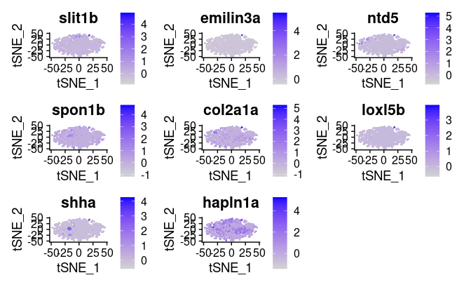

```r
zeb_features <- c("slit1b", "emilin3a", "ntd5", "spon1b", "col2a1a", "loxl5b", "shha", "hapln1a")
  # pec_fin_bud_20_degs[1:9]

FeaturePlot(object = zeb_integrated_50,
            features = zeb_features,
            reduction = "tsne",
            label = FALSE)
```

""" Sanity Checks Below """

```r
zeb_integrated_seurat <- zeb_integrated_50

DimPlot(zeb_integrated_seurat,
        reduction = "tsne",
        label = TRUE,
        group.by = "orig.ident")
```

[output not shown]